# R_Training_2.5

# Exercise 7: Reverse a signal

Set up your workspace:

```r
library(signal)
```

```r
library(tuneR)
library(ggplot2)
library(oce)
library(seewave)
library(gridExtra)
library(DFWE)
```

First we needs a signal – let’s use the zebra finch song

```r
zf_data = readWave('zfinch.wav')
```

Now we reverse it. We extract the relevant data from our wave file, **zf_data@left** and then reorder by specifying a sequence.

```r
zf_data_rev = zf_data@left[seq(to = 1, by = -1, length.out = length(zf_data@left))]
```

We can also halve the sample rate by increasing the **by =** parameter.

```r
zf_data_rev_half = zf_data@left[seq(to = 1, by = -2, length.out = length(zf_data@left)/2)]
```

Thats all there is to it!

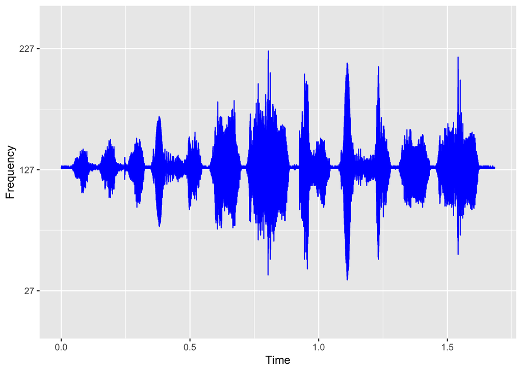

```r
sampleFs = zf_data@samp.rate
tim = seq(1/sampleFs, length(zf_data@left)/sampleFs, 1/sampleFs)
zf_data_plot = data.frame(tim, zf_data@left)

ggplot(zf_data_plot, aes(x = tim, y = zf_data.left)) +
  geom_line(color = "Blue") +
  scale_y_continuous(name = "Frequency", breaks = c(27,127,227), limits = c(0,250)) +
  scale_x_continuous(name = "Time")
```

*Note: When ploting the modified data some parameters need to be manaully set*

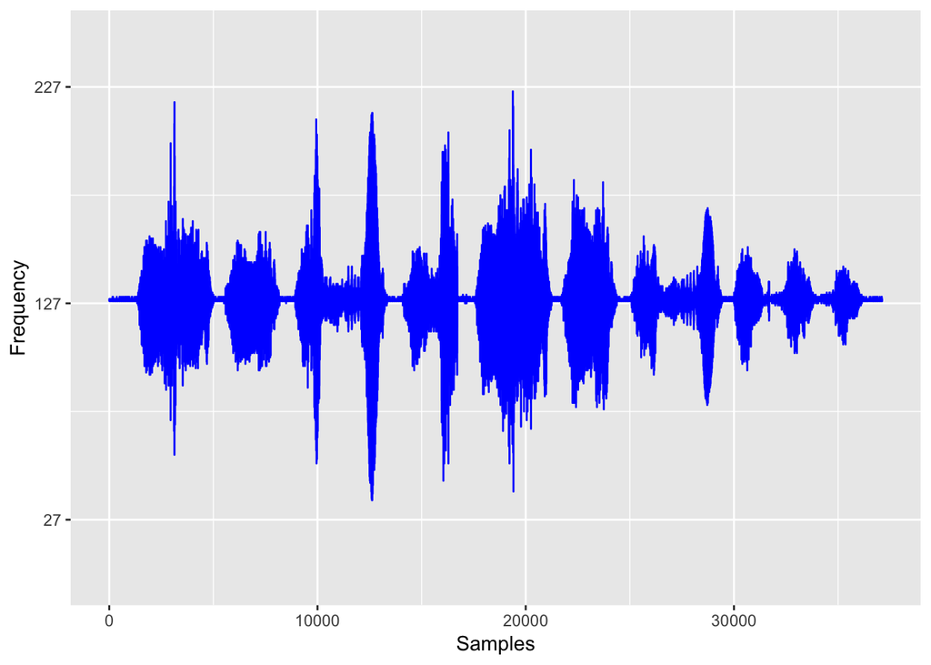

```r
zf_data_rev_plot = data.frame(zf_data_rev, "index" = seq(1,length(zf_data_rev), 1))

ggplot(zf_data_rev_plot, aes(x = index, y = zf_data_rev)) +
  geom_line(color = "Blue") +
  scale_y_continuous(name = "Frequency", breaks = c(27,127,227), limits = c(0,250)) +
  scale_x_continuous(name = "Samples")
```

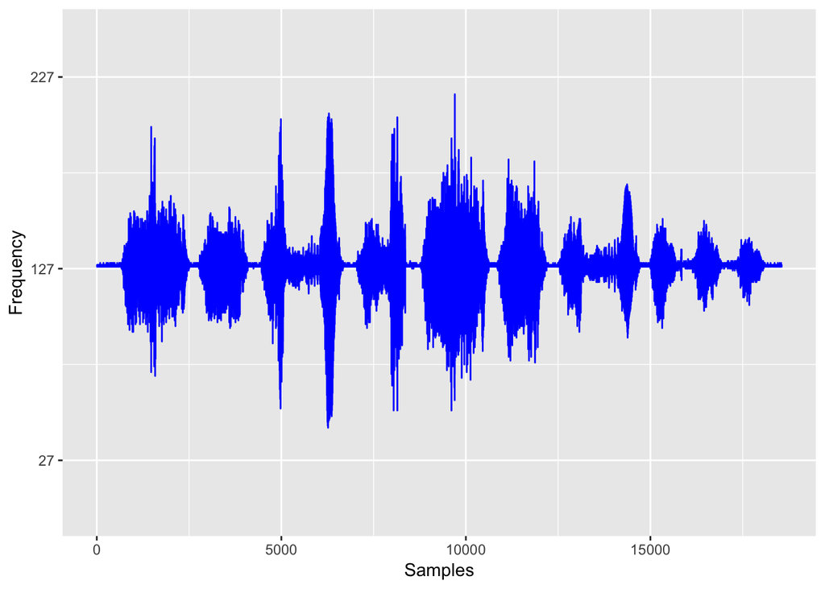

```r
zf_data_rev_half_plot = data.frame(zf_data_rev_half, "index" = seq(1,length(zf_data_rev_half), 1))

ggplot(zf_data_rev_half_plot, aes(x = index, y = zf_data_rev_half)) +
  geom_line(color = "Blue") +
  scale_y_continuous(name = "Frequency", breaks = c(27,127,227), limits = c(0,250)) +
  scale_x_continuous(name = "Samples")
```

# Exercise 8: Finding data with the “Which” function

The **which()** function is a powerful tool which returns the indices of an object that fullfills a given logical statement. We can use this to extract portions of data that meet our parameters and then plot that data to highlight areas of interest

First let’s get a signal and plot it:

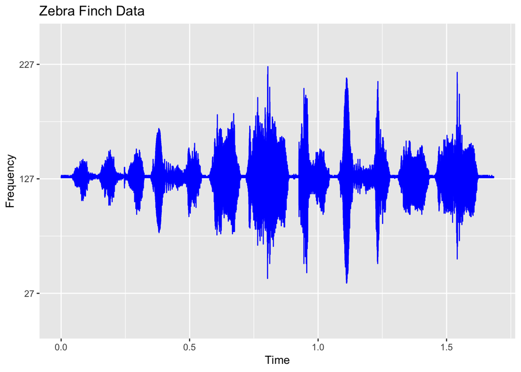

```r
ggplot(zf_data_plot, aes(x = tim, y = zf_data.left)) +
  geom_line(color = "Blue") +
  scale_y_continuous(name = "Frequency", breaks = c(27,127,227), limits = c(0,250)) +
  scale_x_continuous(name = "Time") +
  ggtitle("Zebra Finch Data")
```

```r
zfFs = zf_data@samp.rate
tim = seq(1/zfFs, length(zf_data@left)/zfFs, 1/zfFs)
```

Perhaps we only want to examine the last syllable. We can use the **coord_cartesian()** object in our plot to only view that syllable

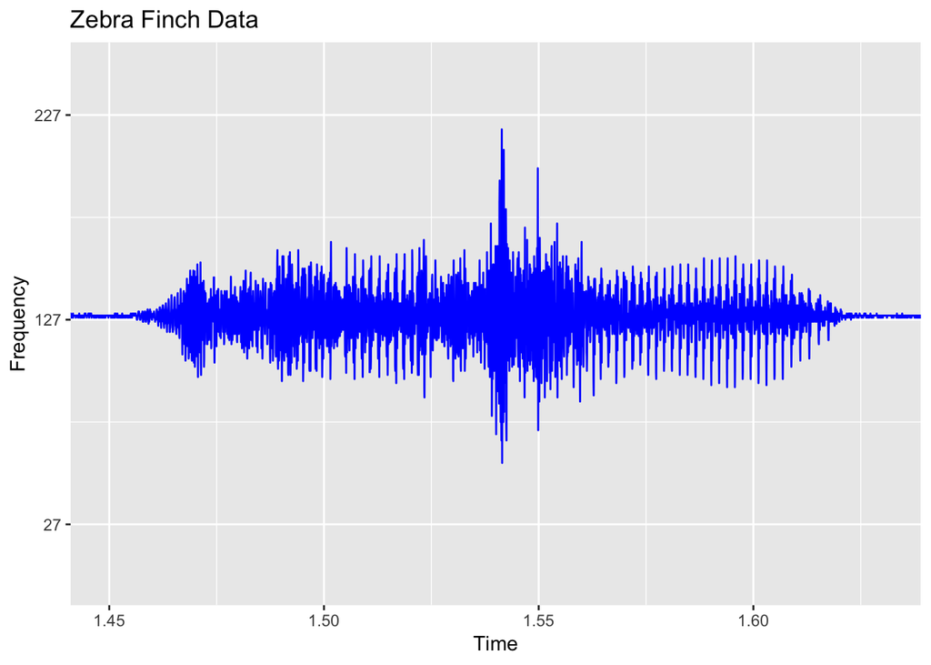

```r
ggplot(zf_data_plot, aes(x = tim, y = zf_data.left)) +
  geom_line(color = "Blue") +
  coord_cartesian(xlim = c(1.45, 1.63)) +
  scale_y_continuous(name = "Frequency", breaks = c(27,127,227), limits = c(0,250)) +
  scale_x_continuous(name = "Time") +
  ggtitle("Zebra Finch Data")
```

This *only* plots the selected x range. What if we want to examine that last syllable *and* still plot the rest of the data?

To do this, we can use the **which** function to find the index of values that meet our criteria (in this case between 1.45 and 1.63). Then we plot that on top of our existing plot.

Lets use **which()** and store the result in variable **pp**:

```r
pp = which(tim >= 1.45 & tim <= 1.63)
```

Now that we’ve found the *positions* of our samples, we can graph by telling R to plot **tim[pp]** and **zf_data@left[pp]**.

In order for our suplot to lineup correctly, we need to create a variable **tmax** to serve as our manual upper x limit.

```r
tmax = tim[length(tim)]
```

Now we can go ahead an plot. Just add another **geom_line()** and change the color!

*Note: Here we didn’t plot using a dataframe. We specified the x and y data within the **geom_line**.*

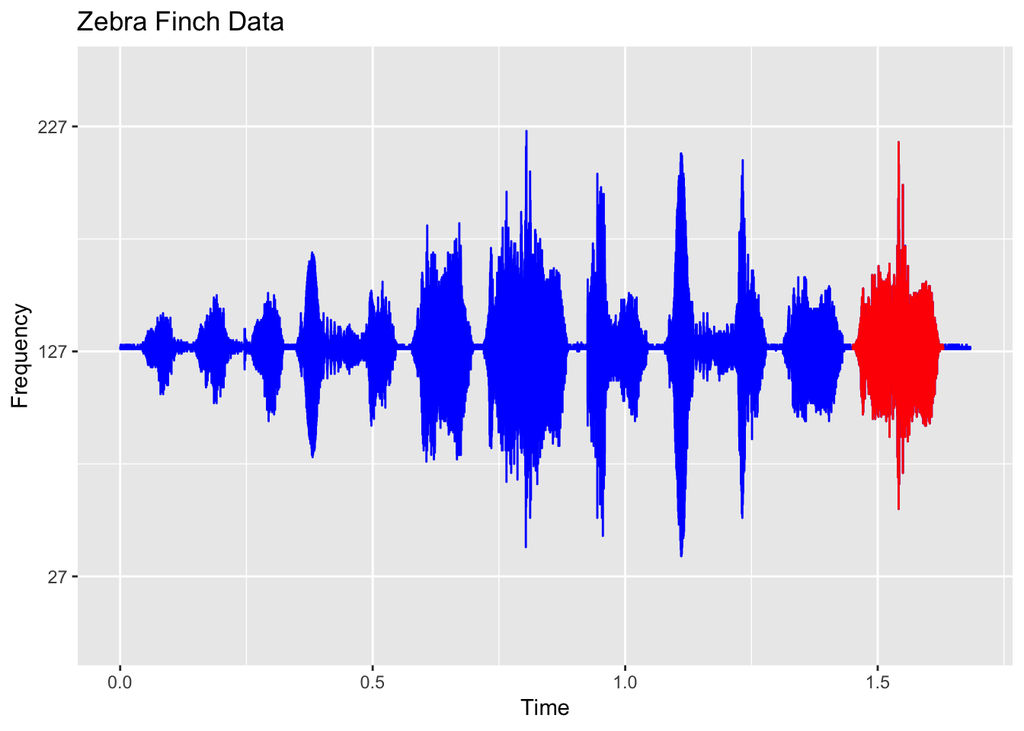

```r
ggplot() +
  geom_line(aes(x = tim, y = zf_data@left), color = "Blue") +
  scale_y_continuous(name = "Frequency", breaks = c(27,127,227), limits = c(0,250)) +
  scale_x_continuous(name = "Time") +
  ggtitle("Zebra Finch Data") +
  geom_line(aes(x = tim[pp], zf_data@left[pp]), colour = "Red")
```

We can do the same thing for the y-axis. Lets select all of the values about *137*.

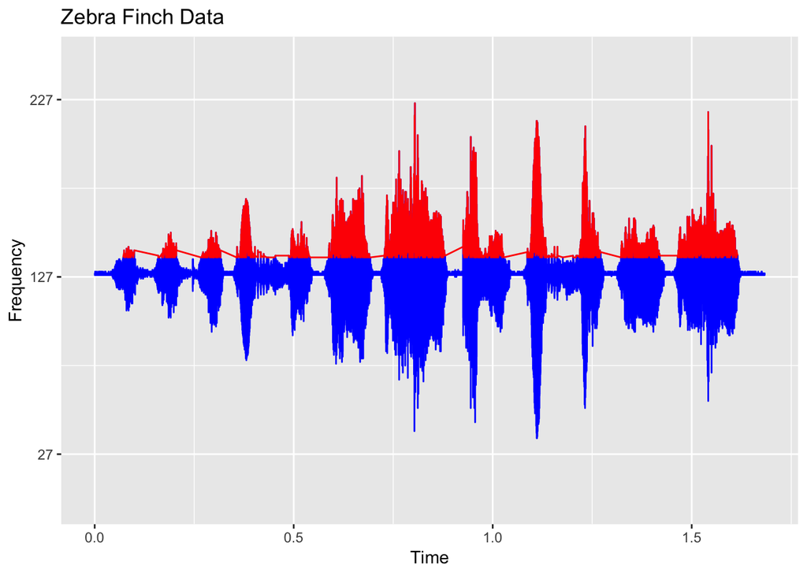

```r
ppy = which(zf_data@left > 137)
ggplot() +
  geom_line(aes(x = tim, y = zf_data@left), color = "Blue") +
  scale_y_continuous(name = "Frequency", breaks = c(27,127,227), limits = c(0,250)) +
  scale_x_continuous(name = "Time") +
  ggtitle("Zebra Finch Data") +
  geom_line(aes(x = tim[ppy], zf_data@left[ppy]), colour = "Red")
```